# Risk Factor Analysis

## Outcome Variable

**Outcome Variable:** haz

## Predictor Variables

**Intervention Variable:** mbmi

**Adjustment Set:**

- arm
- W_mage
- W_fage
- meducyrs
- feducyrs
- single
- brthmon
- W_gagebrth
- W_birthwt
- W_birthlen
- vagbrth
- delta_W_mage
- delta_W_fage
- delta_meducyrs
- delta_feducyrs
- delta_single
- delta_brthmon
- delta_W_gagebrth
- delta_W_birthwt
- delta_W_birthlen
- delta_vagbrth

## Stratifying Variables

The analysis was stratified on these variable(s):

- agecat
- studyid
- country

## Data Summary

| agecat | studyid | country | mbmi | n_cell | n |
| --- | --- | --- | --- | --- | --- |
| 6 months | ki0047075b-MAL-ED | BANGLADESH | Normal weight | 209 | 241 |
| 6 months | ki0047075b-MAL-ED | BANGLADESH | Underweight | 32 | 241 |
| 6 months | ki0047075b-MAL-ED | BRAZIL | Normal weight | 199 | 208 |
| 6 months | ki0047075b-MAL-ED | BRAZIL | Underweight | 9 | 208 |
| 6 months | ki0047075b-MAL-ED | INDIA | Normal weight | 186 | 235 |
| 6 months | ki0047075b-MAL-ED | INDIA | Underweight | 49 | 235 |
| 6 months | ki0047075b-MAL-ED | NEPAL | Normal weight | 236 | 236 |
| 6 months | ki0047075b-MAL-ED | NEPAL | Underweight | 0 | 236 |
| 6 months | ki0047075b-MAL-ED | PERU | Normal weight | 267 | 272 |
| 6 months | ki0047075b-MAL-ED | PERU | Underweight | 5 | 272 |
| 6 months | ki0047075b-MAL-ED | SOUTH AFRICA | Normal weight | 242 | 249 |
| 6 months | ki0047075b-MAL-ED | SOUTH AFRICA | Underweight | 7 | 249 |
| 6 months | ki0047075b-MAL-ED | TANZANIA, UNITED REPUBLIC OF | Normal weight | 233 | 247 |
| 6 months | ki0047075b-MAL-ED | TANZANIA, UNITED REPUBLIC OF | Underweight | 14 | 247 |
| 6 months | ki1000304b-SAS-CompFeed | INDIA | Normal weight | 922 | 1227 |
| 6 months | ki1000304b-SAS-CompFeed | INDIA | Underweight | 305 | 1227 |
| 6 months | ki1017093-NIH-Birth | BANGLADESH | Normal weight | 444 | 537 |
| 6 months | ki1017093-NIH-Birth | BANGLADESH | Underweight | 93 | 537 |
| 6 months | ki1017093b-PROVIDE | BANGLADESH | Normal weight | 481 | 582 |
| 6 months | ki1017093b-PROVIDE | BANGLADESH | Underweight | 101 | 582 |
| 6 months | ki1017093c-NIH-Crypto | BANGLADESH | Normal weight | 648 | 715 |
| 6 months | ki1017093c-NIH-Crypto | BANGLADESH | Underweight | 67 | 715 |
| 6 months | ki1066203-TanzaniaChild2 | TANZANIA, UNITED REPUBLIC OF | Normal weight | 1949 | 1983 |
| 6 months | ki1066203-TanzaniaChild2 | TANZANIA, UNITED REPUBLIC OF | Underweight | 34 | 1983 |
| 6 months | ki1119695-PROBIT | BELARUS | Normal weight | 12522 | 13027 |
| 6 months | ki1119695-PROBIT | BELARUS | Underweight | 505 | 13027 |
| 6 months | ki1126311-ZVITAMBO | ZIMBABWE | Normal weight | 6747 | 7109 |
| 6 months | ki1126311-ZVITAMBO | ZIMBABWE | Underweight | 362 | 7109 |
| 6 months | ki1148112-LCNI-5 | MALAWI | Normal weight | 691 | 836 |
| 6 months | ki1148112-LCNI-5 | MALAWI | Underweight | 145 | 836 |
| 24 months | ki0047075b-MAL-ED | BANGLADESH | Normal weight | 183 | 212 |
| 24 months | ki0047075b-MAL-ED | BANGLADESH | Underweight | 29 | 212 |
| 24 months | ki0047075b-MAL-ED | BRAZIL | Normal weight | 162 | 168 |
| 24 months | ki0047075b-MAL-ED | BRAZIL | Underweight | 6 | 168 |
| 24 months | ki0047075b-MAL-ED | INDIA | Normal weight | 180 | 226 |
| 24 months | ki0047075b-MAL-ED | INDIA | Underweight | 46 | 226 |
| 24 months | ki0047075b-MAL-ED | NEPAL | Normal weight | 228 | 228 |
| 24 months | ki0047075b-MAL-ED | NEPAL | Underweight | 0 | 228 |
| 24 months | ki0047075b-MAL-ED | PERU | Normal weight | 197 | 201 |
| 24 months | ki0047075b-MAL-ED | PERU | Underweight | 4 | 201 |
| 24 months | ki0047075b-MAL-ED | SOUTH AFRICA | Normal weight | 227 | 234 |
| 24 months | ki0047075b-MAL-ED | SOUTH AFRICA | Underweight | 7 | 234 |
| 24 months | ki0047075b-MAL-ED | TANZANIA, UNITED REPUBLIC OF | Normal weight | 203 | 214 |
| 24 months | ki0047075b-MAL-ED | TANZANIA, UNITED REPUBLIC OF | Underweight | 11 | 214 |
| 24 months | ki1017093-NIH-Birth | BANGLADESH | Normal weight | 349 | 429 |
| 24 months | ki1017093-NIH-Birth | BANGLADESH | Underweight | 80 | 429 |
| 24 months | ki1017093b-PROVIDE | BANGLADESH | Normal weight | 476 | 576 |
| 24 months | ki1017093b-PROVIDE | BANGLADESH | Underweight | 100 | 576 |
| 24 months | ki1017093c-NIH-Crypto | BANGLADESH | Normal weight | 471 | 514 |
| 24 months | ki1017093c-NIH-Crypto | BANGLADESH | Underweight | 43 | 514 |
| 24 months | ki1066203-TanzaniaChild2 | TANZANIA, UNITED REPUBLIC OF | Normal weight | 6 | 6 |
| 24 months | ki1066203-TanzaniaChild2 | TANZANIA, UNITED REPUBLIC OF | Underweight | 0 | 6 |
| 24 months | ki1119695-PROBIT | BELARUS | Normal weight | 3863 | 4005 |
| 24 months | ki1119695-PROBIT | BELARUS | Underweight | 142 | 4005 |
| 24 months | ki1126311-ZVITAMBO | ZIMBABWE | Normal weight | 352 | 377 |
| 24 months | ki1126311-ZVITAMBO | ZIMBABWE | Underweight | 25 | 377 |
| 24 months | ki1148112-LCNI-5 | MALAWI | Normal weight | 482 | 577 |
| 24 months | ki1148112-LCNI-5 | MALAWI | Underweight | 95 | 577 |

The following strata were considered:

- agecat: 24 months, studyid: ki0047075b-MAL-ED, country: BANGLADESH
- agecat: 24 months, studyid: ki0047075b-MAL-ED, country: BRAZIL
- agecat: 24 months, studyid: ki0047075b-MAL-ED, country: INDIA
- agecat: 24 months, studyid: ki0047075b-MAL-ED, country: NEPAL
- agecat: 24 months, studyid: ki0047075b-MAL-ED, country: PERU
- agecat: 24 months, studyid: ki0047075b-MAL-ED, country: SOUTH AFRICA
- agecat: 24 months, studyid: ki0047075b-MAL-ED, country: TANZANIA, UNITED REPUBLIC OF
- agecat: 24 months, studyid: ki1017093-NIH-Birth, country: BANGLADESH
- agecat: 24 months, studyid: ki1017093b-PROVIDE, country: BANGLADESH
- agecat: 24 months, studyid: ki1017093c-NIH-Crypto, country: BANGLADESH
- agecat: 24 months, studyid: ki1066203-TanzaniaChild2, country: TANZANIA, UNITED REPUBLIC OF
- agecat: 24 months, studyid: ki1119695-PROBIT, country: BELARUS
- agecat: 24 months, studyid: ki1126311-ZVITAMBO, country: ZIMBABWE
- agecat: 24 months, studyid: ki1148112-LCNI-5, country: MALAWI
- agecat: 6 months, studyid: ki0047075b-MAL-ED, country: BANGLADESH
- agecat: 6 months, studyid: ki0047075b-MAL-ED, country: BRAZIL
- agecat: 6 months, studyid: ki0047075b-MAL-ED, country: INDIA
- agecat: 6 months, studyid: ki0047075b-MAL-ED, country: NEPAL
- agecat: 6 months, studyid: ki0047075b-MAL-ED, country: PERU
- agecat: 6 months, studyid: ki0047075b-MAL-ED, country: SOUTH AFRICA
- agecat: 6 months, studyid: ki0047075b-MAL-ED, country: TANZANIA, UNITED REPUBLIC OF
- agecat: 6 months, studyid: ki1000304b-SAS-CompFeed, country: INDIA
- agecat: 6 months, studyid: ki1017093-NIH-Birth, country: BANGLADESH
- agecat: 6 months, studyid: ki1017093b-PROVIDE, country: BANGLADESH
- agecat: 6 months, studyid: ki1017093c-NIH-Crypto, country: BANGLADESH
- agecat: 6 months, studyid: ki1066203-TanzaniaChild2, country: TANZANIA, UNITED REPUBLIC OF
- agecat: 6 months, studyid: ki1119695-PROBIT, country: BELARUS
- agecat: 6 months, studyid: ki1126311-ZVITAMBO, country: ZIMBABWE
- agecat: 6 months, studyid: ki1148112-LCNI-5, country: MALAWI

### Dropped Strata

Some strata were dropped due to rare outcomes:

- agecat: 6 months, studyid: ki0047075b-MAL-ED, country: NEPAL
- agecat: 24 months, studyid: ki0047075b-MAL-ED, country: NEPAL
- agecat: 24 months, studyid: ki0047075b-MAL-ED, country: PERU
- agecat: 24 months, studyid: ki1066203-TanzaniaChild2, country: TANZANIA, UNITED REPUBLIC OF

## Methods Detail

We’re interested in the causal parameters $E[Y_a]$ for all values of $a \in \mathcal{A}$. These parameters represent the mean outcome if, possibly contrary to fact, we intervened to set all units to have $A=a$. Under the randomization and positivity assumptions, these are identified by the statistical parameters $\psi_a=E_W[E_{Y|A,W}(Y|A=a,W)]$. In addition, we’re interested in the mean of $Y$, $E[Y]$ under no intervention (the observed mean). We will estimate these parameters by using SuperLearner to fit the relevant likelihood factors – $E_{Y|A,W}(Y|A=a,W)$ and $p(A=a|W)$, and then updating our likelihood fit using a joint TMLE.

For unadjusted analyses ($W=\{\}$), initial likelihoods were estimated using Lrnr_glm to estimate the simple $E(Y|A)$ and Lrnr_mean to estimate $p(A)$. For adjusted analyses, a small library containing Lrnr_glmnet, Lrnr_xgboost, and Lrnr_mean was used.

Having estimated these parameters, we will then use the delta method to estimate relative risks and attributable risks relative to a prespecified baseline level of $A$.

# Results Detail

## Results Plots

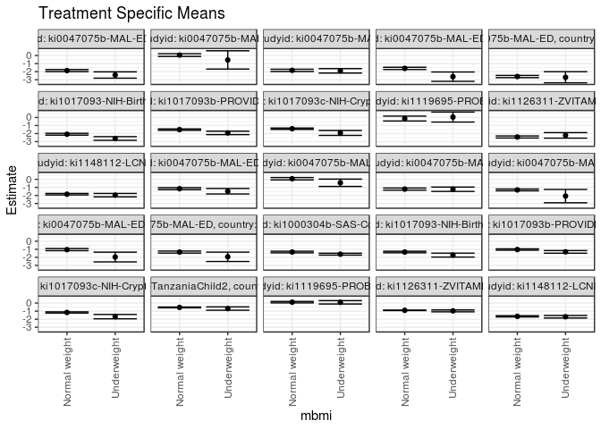

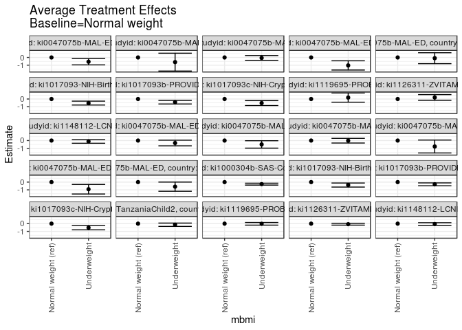

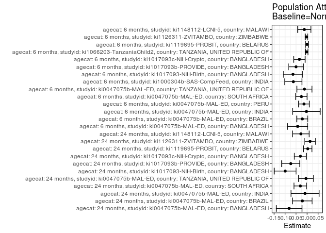

## Results Table

### Parameter: TSM

| agecat | studyid | country | intervention_level | baseline_level | estimate | ci_lower | ci_upper |
| --- | --- | --- | --- | --- | --- | --- | --- |
| 6 months | ki0047075b-MAL-ED | BANGLADESH | Normal weight | NA | -1.1628765 | -1.2884952 | -1.0372577 |
| 6 months | ki0047075b-MAL-ED | BANGLADESH | Underweight | NA | -1.4804918 | -1.8209681 | -1.1400156 |
| 6 months | ki0047075b-MAL-ED | BRAZIL | Normal weight | NA | 0.0748995 | -0.0742030 | 0.2240020 |
| 6 months | ki0047075b-MAL-ED | BRAZIL | Underweight | NA | -0.4262963 | -0.8810079 | 0.0284153 |
| 6 months | ki0047075b-MAL-ED | INDIA | Normal weight | NA | -1.2119273 | -1.3458384 | -1.0780162 |
| 6 months | ki0047075b-MAL-ED | INDIA | Underweight | NA | -1.2294537 | -1.5003129 | -0.9585945 |
| 6 months | ki0047075b-MAL-ED | PERU | Normal weight | NA | -1.3131149 | -1.4218494 | -1.2043803 |
| 6 months | ki0047075b-MAL-ED | PERU | Underweight | NA | -2.0820000 | -2.9100519 | -1.2539481 |
| 6 months | ki0047075b-MAL-ED | SOUTH AFRICA | Normal weight | NA | -1.0469731 | -1.1780219 | -0.9159244 |
| 6 months | ki0047075b-MAL-ED | SOUTH AFRICA | Underweight | NA | -1.9657143 | -2.5717876 | -1.3596410 |
| 6 months | ki0047075b-MAL-ED | TANZANIA, UNITED REPUBLIC OF | Normal weight | NA | -1.3482301 | -1.4722444 | -1.2242158 |
| 6 months | ki0047075b-MAL-ED | TANZANIA, UNITED REPUBLIC OF | Underweight | NA | -1.9378850 | -2.5171961 | -1.3585739 |
| 6 months | ki1000304b-SAS-CompFeed | INDIA | Normal weight | NA | -1.3449333 | -1.4429227 | -1.2469439 |
| 6 months | ki1000304b-SAS-CompFeed | INDIA | Underweight | NA | -1.6092659 | -1.7247064 | -1.4938253 |
| 6 months | ki1017093-NIH-Birth | BANGLADESH | Normal weight | NA | -1.3432972 | -1.4385020 | -1.2480924 |
| 6 months | ki1017093-NIH-Birth | BANGLADESH | Underweight | NA | -1.7251639 | -1.9696632 | -1.4806646 |
| 6 months | ki1017093b-PROVIDE | BANGLADESH | Normal weight | NA | -1.0347364 | -1.1198520 | -0.9496208 |
| 6 months | ki1017093b-PROVIDE | BANGLADESH | Underweight | NA | -1.3250682 | -1.4881944 | -1.1619421 |
| 6 months | ki1017093c-NIH-Crypto | BANGLADESH | Normal weight | NA | -1.1639332 | -1.2378152 | -1.0900511 |
| 6 months | ki1017093c-NIH-Crypto | BANGLADESH | Underweight | NA | -1.6831439 | -1.9541566 | -1.4121311 |
| 6 months | ki1066203-TanzaniaChild2 | TANZANIA, UNITED REPUBLIC OF | Normal weight | NA | -0.5388761 | -0.5892072 | -0.4885450 |
| 6 months | ki1066203-TanzaniaChild2 | TANZANIA, UNITED REPUBLIC OF | Underweight | NA | -0.6799214 | -0.8886043 | -0.4712386 |
| 6 months | ki1119695-PROBIT | BELARUS | Normal weight | NA | 0.1154522 | 0.0227694 | 0.2081351 |
| 6 months | ki1119695-PROBIT | BELARUS | Underweight | NA | 0.0948023 | -0.1120197 | 0.3016243 |
| 6 months | ki1126311-ZVITAMBO | ZIMBABWE | Normal weight | NA | -0.8983293 | -0.9267318 | -0.8699269 |
| 6 months | ki1126311-ZVITAMBO | ZIMBABWE | Underweight | NA | -0.9684707 | -1.0844955 | -0.8524460 |
| 6 months | ki1148112-LCNI-5 | MALAWI | Normal weight | NA | -1.6453192 | -1.7235402 | -1.5670981 |
| 6 months | ki1148112-LCNI-5 | MALAWI | Underweight | NA | -1.6956851 | -1.8509428 | -1.5404274 |
| 24 months | ki0047075b-MAL-ED | BANGLADESH | Normal weight | NA | -1.8616281 | -1.9914278 | -1.7318283 |
| 24 months | ki0047075b-MAL-ED | BANGLADESH | Underweight | NA | -2.4114686 | -2.8012678 | -2.0216695 |
| 24 months | ki0047075b-MAL-ED | BRAZIL | Normal weight | NA | 0.0633642 | -0.1049962 | 0.2317246 |
| 24 months | ki0047075b-MAL-ED | BRAZIL | Underweight | NA | -0.5391667 | -1.6773310 | 0.5989977 |
| 24 months | ki0047075b-MAL-ED | INDIA | Normal weight | NA | -1.8346424 | -1.9767841 | -1.6925008 |
| 24 months | ki0047075b-MAL-ED | INDIA | Underweight | NA | -1.8957492 | -2.1695523 | -1.6219461 |
| 24 months | ki0047075b-MAL-ED | SOUTH AFRICA | Normal weight | NA | -1.5912775 | -1.7294629 | -1.4530921 |
| 24 months | ki0047075b-MAL-ED | SOUTH AFRICA | Underweight | NA | -2.6192857 | -3.1998173 | -2.0387542 |
| 24 months | ki0047075b-MAL-ED | TANZANIA, UNITED REPUBLIC OF | Normal weight | NA | -2.6009506 | -2.7385145 | -2.4633867 |
| 24 months | ki0047075b-MAL-ED | TANZANIA, UNITED REPUBLIC OF | Underweight | NA | -2.6965341 | -3.3880613 | -2.0050070 |
| 24 months | ki1017093-NIH-Birth | BANGLADESH | Normal weight | NA | -2.0812039 | -2.1948739 | -1.9675339 |
| 24 months | ki1017093-NIH-Birth | BANGLADESH | Underweight | NA | -2.6081092 | -2.8334731 | -2.3827453 |
| 24 months | ki1017093b-PROVIDE | BANGLADESH | Normal weight | NA | -1.5097952 | -1.5995201 | -1.4200703 |
| 24 months | ki1017093b-PROVIDE | BANGLADESH | Underweight | NA | -1.9201343 | -2.1339742 | -1.7062945 |
| 24 months | ki1017093c-NIH-Crypto | BANGLADESH | Normal weight | NA | -1.3988735 | -1.4855058 | -1.3122411 |
| 24 months | ki1017093c-NIH-Crypto | BANGLADESH | Underweight | NA | -1.9241601 | -2.2289442 | -1.6193761 |
| 24 months | ki1119695-PROBIT | BELARUS | Normal weight | NA | -0.1352963 | -0.4381790 | 0.1675864 |
| 24 months | ki1119695-PROBIT | BELARUS | Underweight | NA | 0.0502800 | -0.5719414 | 0.6725015 |
| 24 months | ki1126311-ZVITAMBO | ZIMBABWE | Normal weight | NA | -2.4272154 | -2.5567772 | -2.2976536 |
| 24 months | ki1126311-ZVITAMBO | ZIMBABWE | Underweight | NA | -2.2257764 | -2.5702768 | -1.8812759 |
| 24 months | ki1148112-LCNI-5 | MALAWI | Normal weight | NA | -1.8463543 | -1.9363108 | -1.7563978 |
| 24 months | ki1148112-LCNI-5 | MALAWI | Underweight | NA | -1.9642201 | -2.1777524 | -1.7506879 |

### Parameter: E(Y)

| agecat | studyid | country | intervention_level | baseline_level | estimate | ci_lower | ci_upper |
| --- | --- | --- | --- | --- | --- | --- | --- |
| 6 months | ki0047075b-MAL-ED | BANGLADESH | NA | NA | -1.2056777 | -1.3231497 | -1.0882058 |
| 6 months | ki0047075b-MAL-ED | BRAZIL | NA | NA | 0.0532131 | -0.0914567 | 0.1978830 |
| 6 months | ki0047075b-MAL-ED | INDIA | NA | NA | -1.2148369 | -1.3332371 | -1.0964367 |
| 6 months | ki0047075b-MAL-ED | PERU | NA | NA | -1.3272488 | -1.4359649 | -1.2185326 |
| 6 months | ki0047075b-MAL-ED | SOUTH AFRICA | NA | NA | -1.0728012 | -1.2026830 | -0.9429194 |
| 6 months | ki0047075b-MAL-ED | TANZANIA, UNITED REPUBLIC OF | NA | NA | -1.3601215 | -1.4821830 | -1.2380600 |
| 6 months | ki1000304b-SAS-CompFeed | INDIA | NA | NA | -1.4072209 | -1.4983514 | -1.3160903 |
| 6 months | ki1017093-NIH-Birth | BANGLADESH | NA | NA | -1.4073821 | -1.4960598 | -1.3187043 |
| 6 months | ki1017093b-PROVIDE | BANGLADESH | NA | NA | -1.0848568 | -1.1613109 | -1.0084028 |
| 6 months | ki1017093c-NIH-Crypto | BANGLADESH | NA | NA | -1.1986783 | -1.2700937 | -1.1272630 |
| 6 months | ki1066203-TanzaniaChild2 | TANZANIA, UNITED REPUBLIC OF | NA | NA | -0.5405711 | -0.5899965 | -0.4911457 |
| 6 months | ki1119695-PROBIT | BELARUS | NA | NA | 0.1153731 | 0.0222128 | 0.2085334 |
| 6 months | ki1126311-ZVITAMBO | ZIMBABWE | NA | NA | -0.9008757 | -0.9285733 | -0.8731780 |
| 6 months | ki1148112-LCNI-5 | MALAWI | NA | NA | -1.6577751 | -1.7275296 | -1.5880207 |
| 24 months | ki0047075b-MAL-ED | BANGLADESH | NA | NA | -1.9431132 | -2.0691678 | -1.8170586 |
| 24 months | ki0047075b-MAL-ED | BRAZIL | NA | NA | 0.0418452 | -0.1263708 | 0.2100613 |
| 24 months | ki0047075b-MAL-ED | INDIA | NA | NA | -1.8439159 | -1.9704751 | -1.7173568 |
| 24 months | ki0047075b-MAL-ED | SOUTH AFRICA | NA | NA | -1.6220299 | -1.7590593 | -1.4850005 |
| 24 months | ki0047075b-MAL-ED | TANZANIA, UNITED REPUBLIC OF | NA | NA | -2.6058879 | -2.7403043 | -2.4714714 |
| 24 months | ki1017093-NIH-Birth | BANGLADESH | NA | NA | -2.1807945 | -2.2835902 | -2.0779987 |
| 24 months | ki1017093b-PROVIDE | BANGLADESH | NA | NA | -1.5839236 | -1.6672059 | -1.5006413 |
| 24 months | ki1017093c-NIH-Crypto | BANGLADESH | NA | NA | -1.4295331 | -1.5127726 | -1.3462935 |
| 24 months | ki1119695-PROBIT | BELARUS | NA | NA | -0.1322181 | -0.4300523 | 0.1656161 |
| 24 months | ki1126311-ZVITAMBO | ZIMBABWE | NA | NA | -2.4135279 | -2.5366872 | -2.2903685 |
| 24 months | ki1148112-LCNI-5 | MALAWI | NA | NA | -1.8744367 | -1.9556750 | -1.7931984 |

### Parameter: ATE

| agecat | studyid | country | intervention_level | baseline_level | estimate | ci_lower | ci_upper |
| --- | --- | --- | --- | --- | --- | --- | --- |
| 6 months | ki0047075b-MAL-ED | BANGLADESH | Normal weight | Normal weight | 0.0000000 | 0.0000000 | 0.0000000 |
| 6 months | ki0047075b-MAL-ED | BANGLADESH | Underweight | Normal weight | -0.3176154 | -0.6808995 | 0.0456687 |
| 6 months | ki0047075b-MAL-ED | BRAZIL | Normal weight | Normal weight | 0.0000000 | 0.0000000 | 0.0000000 |
| 6 months | ki0047075b-MAL-ED | BRAZIL | Underweight | Normal weight | -0.5011958 | -0.9797291 | -0.0226625 |
| 6 months | ki0047075b-MAL-ED | INDIA | Normal weight | Normal weight | 0.0000000 | 0.0000000 | 0.0000000 |
| 6 months | ki0047075b-MAL-ED | INDIA | Underweight | Normal weight | -0.0175264 | -0.3208549 | 0.2858021 |
| 6 months | ki0047075b-MAL-ED | PERU | Normal weight | Normal weight | 0.0000000 | 0.0000000 | 0.0000000 |
| 6 months | ki0047075b-MAL-ED | PERU | Underweight | Normal weight | -0.7688851 | -1.6040457 | 0.0662754 |
| 6 months | ki0047075b-MAL-ED | SOUTH AFRICA | Normal weight | Normal weight | 0.0000000 | 0.0000000 | 0.0000000 |
| 6 months | ki0047075b-MAL-ED | SOUTH AFRICA | Underweight | Normal weight | -0.9187411 | -1.5388207 | -0.2986616 |
| 6 months | ki0047075b-MAL-ED | TANZANIA, UNITED REPUBLIC OF | Normal weight | Normal weight | 0.0000000 | 0.0000000 | 0.0000000 |
| 6 months | ki0047075b-MAL-ED | TANZANIA, UNITED REPUBLIC OF | Underweight | Normal weight | -0.5896549 | -1.1800477 | 0.0007379 |
| 6 months | ki1000304b-SAS-CompFeed | INDIA | Normal weight | Normal weight | 0.0000000 | 0.0000000 | 0.0000000 |
| 6 months | ki1000304b-SAS-CompFeed | INDIA | Underweight | Normal weight | -0.2643326 | -0.3856616 | -0.1430035 |
| 6 months | ki1017093-NIH-Birth | BANGLADESH | Normal weight | Normal weight | 0.0000000 | 0.0000000 | 0.0000000 |
| 6 months | ki1017093-NIH-Birth | BANGLADESH | Underweight | Normal weight | -0.3818667 | -0.6441578 | -0.1195756 |
| 6 months | ki1017093b-PROVIDE | BANGLADESH | Normal weight | Normal weight | 0.0000000 | 0.0000000 | 0.0000000 |
| 6 months | ki1017093b-PROVIDE | BANGLADESH | Underweight | Normal weight | -0.2903318 | -0.4749280 | -0.1057356 |
| 6 months | ki1017093c-NIH-Crypto | BANGLADESH | Normal weight | Normal weight | 0.0000000 | 0.0000000 | 0.0000000 |
| 6 months | ki1017093c-NIH-Crypto | BANGLADESH | Underweight | Normal weight | -0.5192107 | -0.8009358 | -0.2374856 |
| 6 months | ki1066203-TanzaniaChild2 | TANZANIA, UNITED REPUBLIC OF | Normal weight | Normal weight | 0.0000000 | 0.0000000 | 0.0000000 |
| 6 months | ki1066203-TanzaniaChild2 | TANZANIA, UNITED REPUBLIC OF | Underweight | Normal weight | -0.1410453 | -0.3547797 | 0.0726892 |
| 6 months | ki1119695-PROBIT | BELARUS | Normal weight | Normal weight | 0.0000000 | 0.0000000 | 0.0000000 |
| 6 months | ki1119695-PROBIT | BELARUS | Underweight | Normal weight | -0.0206499 | -0.1919054 | 0.1506055 |
| 6 months | ki1126311-ZVITAMBO | ZIMBABWE | Normal weight | Normal weight | 0.0000000 | 0.0000000 | 0.0000000 |
| 6 months | ki1126311-ZVITAMBO | ZIMBABWE | Underweight | Normal weight | -0.0701414 | -0.1886005 | 0.0483177 |
| 6 months | ki1148112-LCNI-5 | MALAWI | Normal weight | Normal weight | 0.0000000 | 0.0000000 | 0.0000000 |
| 6 months | ki1148112-LCNI-5 | MALAWI | Underweight | Normal weight | -0.0503659 | -0.2243476 | 0.1236158 |
| 24 months | ki0047075b-MAL-ED | BANGLADESH | Normal weight | Normal weight | 0.0000000 | 0.0000000 | 0.0000000 |
| 24 months | ki0047075b-MAL-ED | BANGLADESH | Underweight | Normal weight | -0.5498406 | -0.9582243 | -0.1414569 |
| 24 months | ki0047075b-MAL-ED | BRAZIL | Normal weight | Normal weight | 0.0000000 | 0.0000000 | 0.0000000 |
| 24 months | ki0047075b-MAL-ED | BRAZIL | Underweight | Normal weight | -0.6025309 | -1.7530800 | 0.5480183 |
| 24 months | ki0047075b-MAL-ED | INDIA | Normal weight | Normal weight | 0.0000000 | 0.0000000 | 0.0000000 |
| 24 months | ki0047075b-MAL-ED | INDIA | Underweight | Normal weight | -0.0611068 | -0.3697059 | 0.2474923 |
| 24 months | ki0047075b-MAL-ED | SOUTH AFRICA | Normal weight | Normal weight | 0.0000000 | 0.0000000 | 0.0000000 |
| 24 months | ki0047075b-MAL-ED | SOUTH AFRICA | Underweight | Normal weight | -1.0280082 | -1.6247594 | -0.4312569 |
| 24 months | ki0047075b-MAL-ED | TANZANIA, UNITED REPUBLIC OF | Normal weight | Normal weight | 0.0000000 | 0.0000000 | 0.0000000 |
| 24 months | ki0047075b-MAL-ED | TANZANIA, UNITED REPUBLIC OF | Underweight | Normal weight | -0.0955836 | -0.8009088 | 0.6097416 |
| 24 months | ki1017093-NIH-Birth | BANGLADESH | Normal weight | Normal weight | 0.0000000 | 0.0000000 | 0.0000000 |
| 24 months | ki1017093-NIH-Birth | BANGLADESH | Underweight | Normal weight | -0.5269054 | -0.7786734 | -0.2751373 |
| 24 months | ki1017093b-PROVIDE | BANGLADESH | Normal weight | Normal weight | 0.0000000 | 0.0000000 | 0.0000000 |
| 24 months | ki1017093b-PROVIDE | BANGLADESH | Underweight | Normal weight | -0.4103391 | -0.6414465 | -0.1792318 |
| 24 months | ki1017093c-NIH-Crypto | BANGLADESH | Normal weight | Normal weight | 0.0000000 | 0.0000000 | 0.0000000 |
| 24 months | ki1017093c-NIH-Crypto | BANGLADESH | Underweight | Normal weight | -0.5252867 | -0.8428679 | -0.2077055 |
| 24 months | ki1119695-PROBIT | BELARUS | Normal weight | Normal weight | 0.0000000 | 0.0000000 | 0.0000000 |
| 24 months | ki1119695-PROBIT | BELARUS | Underweight | Normal weight | 0.1855764 | -0.4130747 | 0.7842274 |
| 24 months | ki1126311-ZVITAMBO | ZIMBABWE | Normal weight | Normal weight | 0.0000000 | 0.0000000 | 0.0000000 |
| 24 months | ki1126311-ZVITAMBO | ZIMBABWE | Underweight | Normal weight | 0.2014390 | -0.1662795 | 0.5691576 |
| 24 months | ki1148112-LCNI-5 | MALAWI | Normal weight | Normal weight | 0.0000000 | 0.0000000 | 0.0000000 |
| 24 months | ki1148112-LCNI-5 | MALAWI | Underweight | Normal weight | -0.1178658 | -0.3500724 | 0.1143408 |

### Parameter: PAR

| agecat | studyid | country | intervention_level | baseline_level | estimate | ci_lower | ci_upper |
| --- | --- | --- | --- | --- | --- | --- | --- |
| 6 months | ki0047075b-MAL-ED | BANGLADESH | Normal weight | NA | -0.0428013 | -0.0886081 | 0.0030056 |
| 6 months | ki0047075b-MAL-ED | BRAZIL | Normal weight | NA | -0.0216864 | -0.0466204 | 0.0032477 |
| 6 months | ki0047075b-MAL-ED | INDIA | Normal weight | NA | -0.0029095 | -0.0653142 | 0.0594951 |
| 6 months | ki0047075b-MAL-ED | PERU | Normal weight | NA | -0.0141339 | -0.0383650 | 0.0100972 |
| 6 months | ki0047075b-MAL-ED | SOUTH AFRICA | Normal weight | NA | -0.0258281 | -0.0515400 | -0.0001162 |
| 6 months | ki0047075b-MAL-ED | TANZANIA, UNITED REPUBLIC OF | Normal weight | NA | -0.0118914 | -0.0461602 | 0.0223775 |
| 6 months | ki1000304b-SAS-CompFeed | INDIA | Normal weight | NA | -0.0622876 | -0.1013765 | -0.0231986 |
| 6 months | ki1017093-NIH-Birth | BANGLADESH | Normal weight | NA | -0.0640848 | -0.1080498 | -0.0201198 |
| 6 months | ki1017093b-PROVIDE | BANGLADESH | Normal weight | NA | -0.0501204 | -0.0831636 | -0.0170772 |
| 6 months | ki1017093c-NIH-Crypto | BANGLADESH | Normal weight | NA | -0.0347451 | -0.0605841 | -0.0089062 |
| 6 months | ki1066203-TanzaniaChild2 | TANZANIA, UNITED REPUBLIC OF | Normal weight | NA | -0.0016950 | -0.0074517 | 0.0040617 |
| 6 months | ki1119695-PROBIT | BELARUS | Normal weight | NA | -0.0000792 | -0.0065921 | 0.0064337 |
| 6 months | ki1126311-ZVITAMBO | ZIMBABWE | Normal weight | NA | -0.0025463 | -0.0082777 | 0.0031851 |
| 6 months | ki1148112-LCNI-5 | MALAWI | Normal weight | NA | -0.0124559 | -0.0424432 | 0.0175313 |
| 24 months | ki0047075b-MAL-ED | BANGLADESH | Normal weight | NA | -0.0814852 | -0.1399360 | -0.0230343 |
| 24 months | ki0047075b-MAL-ED | BRAZIL | Normal weight | NA | -0.0215190 | -0.0659720 | 0.0229341 |
| 24 months | ki0047075b-MAL-ED | INDIA | Normal weight | NA | -0.0092735 | -0.0731245 | 0.0545775 |
| 24 months | ki0047075b-MAL-ED | SOUTH AFRICA | Normal weight | NA | -0.0307524 | -0.0594630 | -0.0020418 |
| 24 months | ki0047075b-MAL-ED | TANZANIA, UNITED REPUBLIC OF | Normal weight | NA | -0.0049373 | -0.0384407 | 0.0285661 |
| 24 months | ki1017093-NIH-Birth | BANGLADESH | Normal weight | NA | -0.0995906 | -0.1493155 | -0.0498658 |
| 24 months | ki1017093b-PROVIDE | BANGLADESH | Normal weight | NA | -0.0741284 | -0.1152173 | -0.0330395 |
| 24 months | ki1017093c-NIH-Crypto | BANGLADESH | Normal weight | NA | -0.0306596 | -0.0581903 | -0.0031290 |
| 24 months | ki1119695-PROBIT | BELARUS | Normal weight | NA | 0.0030783 | -0.0160729 | 0.0222295 |
| 24 months | ki1126311-ZVITAMBO | ZIMBABWE | Normal weight | NA | 0.0136875 | -0.0103300 | 0.0377051 |
| 24 months | ki1148112-LCNI-5 | MALAWI | Normal weight | NA | -0.0280824 | -0.0656342 | 0.0094694 |